# Exploratory Analysis of Amazon Marketplace Products

Annie Lu al0907@uw.edu

2024-05-12

Keywords: Amazon, online marketplace, ecommerce, business, product sales

Affiliation: University of Washington INFO 201

## Abstract

Our main question is "How are the ratings of a product on Amazon correlated with the price of the product?" This question is important because as consumers generally prefer lower priced items, we want to determine if there is any correlation between items with a lower price point and the satisfaction of consumers, whether it be due to quality, uses, and so on. To address the question, we will conduct research in RStudio using R in order to see if there are any relationships between a product and its rating.

We are concerned with how customers rate products, because a rating determines essentially what the customers liked and disliked about a specific product. To address this concern, we plan to take the ratings of the products, and through our findings, uncover the reviews behind the rating for these products, to get a deeper insight into why customers rated the product the way they did (looking for keywords). Then, to tie this information back to the research question, we will be making inferences about the ratings and the price point of the items based off the reviews.

Consider that the data only has ratings of products, and the ratings are averaged for each product. This is important because we do not know the spread of the ratings for the products, and we are missing key words that reviews would give us regarding what customers think about the product. Accordingly, we plan to do our analysis by first separating the products by category, then investigating the correlation between price and rating, and then, looking up the product given the URL in order to observe the distribution of the ratings and do more analysis regarding the distribution and the keywords from the reviews of the product.

## Introduction

This study aims to investigate the relationship between the price of a product sold on Amazon, and its rating. The results from this study will be used to drive design decisions for what types of products businesses on Amazon should release in order to leave consumers satisfied with both price and condition/usefulness/durability of a product.

1. Which categories have the best selling Amazon products?
- This question is asked in order to find out which categories have the highest number of sales and best-selling products (denoted by a boolean).This question is important because we want to find out which categories have a lot of sales first, so we can compare ratings and their prices within each category to narrow our research scope.
2. Which Amazon product(s) have the most sales?
- This question is asked in order to find which Amazon products overall have the highest number of sales. This question is important because after finding the categories with the best selling Amazon products, we want to find individual products in order to research them specifically and read reviews to connect them to the rating the reviewer gave.
3. What are the cheapest/most expensive products sold on Amazon?
- This question is asked in order to gauge pricing of a product on Amazon. This question is important as it is an exploratory glimpse into what items are priced higher or lower, so we can research the individual products and read reviews to connect them to the rating the reviewer gave.
4. What is the average price of products per category on Amazon?
- This question is asked in order to gauge pricing of a product within a category on Amazon. This quesiton is important because we want to get a sense of which categories of products will have cheaper items, and which will have more expensive items.
5. How are ratings of a product on Amazon correlated with the price of the product?
- This question is asked as our main research question. This question is important because we want to investigate the products where the price of an item where it is cheap enough to satisfy consumers, yet also good enough to encourage the customer to leave a good review, in order to give insights for businesses on Amazon on how they should design their products to reach this balance point between price and satisfaction.

## Related Work

There has been a lot of research done for what products are best-selling on Amazon.

This first research project on Kaggle [3] is a project that uses the Amazon Products dataset as outlined in the section below. It is coded in Python and goes to research top 25 categories of products sold, and more specifically, which products had the highest number of units sold. It also includes the most expensive products sold. A lot of research is similar to what this project will cover, but this project will be researching the datasets using R programming language.

This second blog post from Helium 10 [1] contains information about the top 25 best selling products on Amazon in April 2024. It is targeted towards sellers who aim to start or grow a business on Amazon. It rates the product using three different categories of criteria: product images, listing text, and reviews & ratings, and depending on how many criteria (i.e. one criteria under "product images" is if the product has 7 or more images) the product satisfies, it is ranking according in this article. This article gives a great general idea of what products sell well on Amazon.

Finally, the third post, a blog post from SellerApp [2], contains information on how to find top-selling products on Amazon. It analyzes the top selling products along with best-selling categories on Amazon, which products are growing, and how a seller can choose a product and product category to sell in.

While these three articles covered how to find top-selling products on Amazon, and what determines a top-selling product, this project proposal aims to uncover a new scope using R as a programming language. It aims to find relationships between ratings and price of items, which the Kaggle project did not do, and these relationships will be used for recommending how businesses could design products better for their customers.

[1] Helium 10. (n.d.). Top Selling Items on Amazon. Helium 10 Blog. Retrieved from https://www.helium10.com/blog/top-selling-items-on-amazon/

[2] SellerApp. (n.d.). Best Selling Products on Amazon. SellerApp Blog. Retrieved from https://www.sellerapp.com/blog/best-selling-products-on-amazon/

[3] Sevta, K. (n.d.). Best Products to Sell on Amazon. Kaggle. Retrieved from https://www.kaggle.com/code/ksevta/best-products-to-sell-on-amazon

## Dataset

I found the data on Kaggle. It was one of the recommended datasets when I looked for datasets related to e-commerce. The dataset can be found at https://www.kaggle.com/datasets/asaniczka/amazon-products-dataset-2023-1-4m-products/data?select=amazon_products.csv.

The person that collected the data was a user named ASANICZKA.

The data from the csv files were scraped from Amazon.com.

The data was collected in order to get an in-depth idea of what products sell best, which SEO titles generate the most sales, the best price range for a product in a given category, and much more.

Rows: 1426337

Columns: 11 in amazon-products.csv

## Implications

The implications of this project will be that business owners on Amazon can use these guidelines in order to determine what products to sell and if they are currently selling items, they can use the results of this project to determine how to improve the designs of their products to make customers satisfied. Designers of these products can take into account how the ratings and price points of the products relate in order to meet business needs. These business needs may involve changing the features of a product, lowering cost, etc., all which industrial designers play a part in. Companies will have to consider how to create balance between cost and functionality in order to not only keep their existing customers, but encourage new ones to buy their product. The findings from this project may help drive that. Overall, the results of this project mainly aim to improve business on Amazon for sellers and their products.

## Limitations

The limitations/problems with this dataset are that first, it does not have the reviews of a product given, only the rating. The reviews would be very useful for this project as they have key words that, when analyzed, could discover issues and satisfactory parts of the product that the customer bought, depending on if they left a good or bad review. Second, the rating appears to be averaged, as there is only one rating for each product, and not a distribution of 1-5 star ratings, so this has to be accounted for because the average may not account for, a 1-star rating when majority are 5-stars for example.

## Summary

The 5 summary statistics calculated are the number of Amazon products in the condensed amazon_all dataset, the maximum price of all values in the amazon_all dataset, the maximum star rating of all values in the amazon_all dataset, the highest number of purchases in the last month in the amazon_all dataset, and the category that contains the most bestsellers in the amazon_all dataset. These summary statistics were chosen to answer the research questions 1-3 as stated under Introduction.

There are 110443 rows/products in this dataset. The maximum price found for products in this dataset was $3199. The maximum rating found for products in this dataset was 5 stars. The highest number of people that purchased a specific product in the last month was 100,000. The category with the most bestselling products was "Automative Tools & Equipment" with a total of 139 bestsellers. These are basic statistics to get an idea of what values we are working with, and they will be expanded on in the charts.

```r
library(dplyr)
# read csv
amazon_all <- read.csv("/Users/annielu/Desktop/info201 hw/exploratory-analysis-lu-annie/amazon_all.csv")

summary_info <- list()

# calculates num rows
summary_info$num_observations <- nrow(amazon_all)

# calculates max price
summary_info$max_price <- amazon_all %>%
  filter(price == max(price, na.rm = T)) %>%
  select(price)

# calculates max rating
summary_info$max_rating <- amazon_all %>%
  filter(stars == max(stars, na.rm = T)) %>%
  select(stars)

# calculated most purchased recently
summary_info$most_bought_recently <- amazon_all %>%
  filter(boughtInLastMonth == max(boughtInLastMonth, na.rm = T)) %>%
  select(boughtInLastMonth)

# calculates category with the most bestsellers
summary_info$category_most_bestsellers  <- amazon_all %>%
  group_by(category_name) %>%
  filter(isBestSeller == "True") %>%
  summarize(count = n()) %>%
  arrange(desc(count)) %>%
  slice(1) %>%
  select(category_name, count)
```

## Data Cleaning Code

This code was used to clean the original dataset, which had 1.4 million rows. Because the dataset was too large for processing, I've condensed the original dataset into amazon_all, which filters out any products that had 0 reviews and 0 people who bought it in the last month to ensure that the products in the dataset were actually purchased and tested by many people. This is another limitation to account for in this Amazon products analysis. amazon_all will be the dataset that is used for future analysis.

```r
#library(dplyr)

#amazon_products <- read.csv("/Users/annielu/Downloads/amazon_products.csv")
#amazon_categories <- read.csv("/Users/annielu/Downloads/amazon_categories.csv")

#amazon_all <- full_join(amazon_products, amazon_categories, by = c("category_id" = "id"))

#amazon_all <- amazon_all %>%
 # group_by(category_name) %>%
 # filter(reviews != 0) %>%
# filter(boughtInLastMonth != 0)

#file_path <- "/Users/annielu/Downloads/amazon_all.csv"
#write.csv(amazon_all, file = file_path, row.names = FALSE)
```

## Table

This table is included to showcase what the filtered Amazon products dataset looks like. The dataset has 110k rows, so this code will only show the first 6 rows in alphabetical order. By knowing column and row contents, this will be the background for understanding how the charts were created to find relationships in the data.

The table is grouped by category and reveals what the average price, average rating, and average number of reviews there are for each category. This summarized table of categories with averages can be the starting point for revealing information related to research questions 1 - 5.

```r
library(dplyr)

# read csv
amazon_all <- read.csv("/Users/annielu/Desktop/info201 hw/exploratory-analysis-lu-annie/amazon_all.csv")

# group table by category name and calculate average price, stars, and num reviews
amazon_all_table <- amazon_all %>%
  select(category_name, stars, reviews, price) %>%
  group_by(category_name) %>%
  summarize(
    average_stars = mean(stars),
    average_no_reviews = mean(reviews),
    average_price = mean(price)
  )

# displays short ver of table
head(amazon_all_table)
```

```
## # A tibble: 6 × 4
##   category_name                   average_stars average_no_reviews average_price
##   <chr>                                   <dbl>              <dbl>         <dbl>
## 1 Abrasive & Finishing Products            4.55              1404           14.3
## 2 Additive Manufacturing Products          4.45               717.          44.6
## 3 Arts & Crafts Supplies                   4.54               788.          13.4
## 4 Automotive Exterior Accessories          4.46               777.          28.3
## 5 Automotive Tires & Wheels                4.42               980.          36.8
## 6 Automotive Tools & Equipment             4.47              1069.          47.4
```

## Chart 1

The insights from Chart 1 are that products with an average rating between 1 - 1.9 stars had a higher average price of product compared to anything rated 2 stars and above. For products rated between 1 - 1.9 stars, the average price was $40, which was greater than the other bins as seen in the chart below. Many factors could contribute to this higher average - some being that customers rated the product lower due to the high price, higher priced items may have had faulty parts, etc.

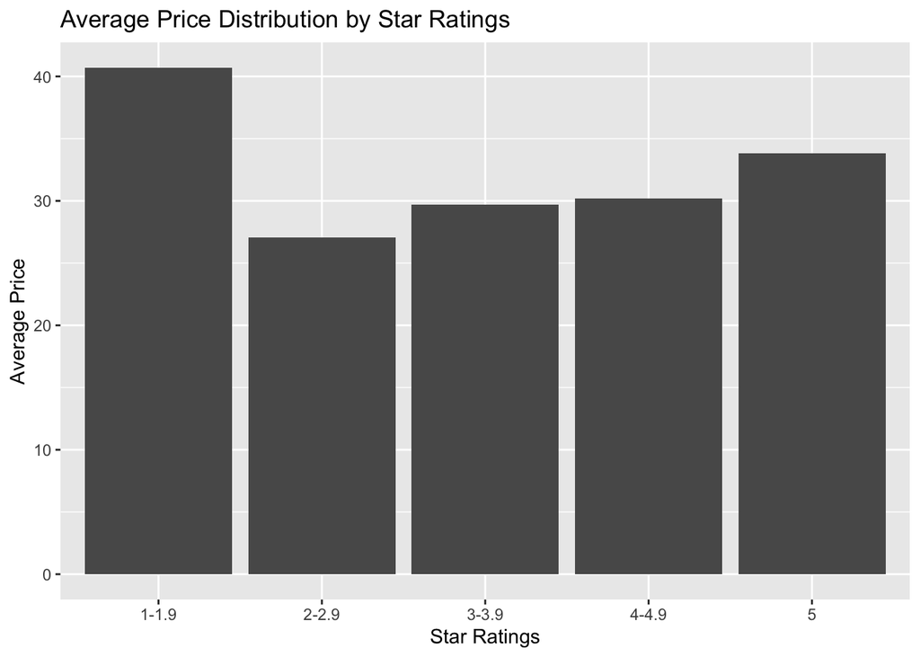

```r
library(ggplot2)
library(dplyr)

# read csv
amazon_all <- read.csv("/Users/annielu/Desktop/info201 hw/exploratory-analysis-lu-annie/amazon_all.csv")

# select only stars and price
amazon_all <- select(amazon_all, stars, price)

# create bins for histogram and calculate mean prices
amazon_all <- amazon_all %>%
  mutate(bins = cut(stars, breaks = seq(1, 6, by = 1), labels = c("1-1.9", "2-2.9", "3-3.9", "4-4.9", "5"))) %>%
  group_by(bins) %>%
  summarize(price = mean(price))

# plot histogram with ggplot2
ggplot(amazon_all, aes(x = bins, y = price)) +
  geom_histogram(stat = "identity") +
  labs(title = "Average Price Distribution by Star Ratings",
       x = "Star Ratings",
       y = "Average Price") +
  scale_x_discrete(labels = c("1-1.9", "2-2.9", "3-3.9", "4-4.9", "5"))
```

## Chart 2

The purpose of Chart 2 is to find the relationship between price and purchases of a product in the amazon_all dataset. The findings are intended to answer or find insights toward question 2: Which Amazon product(s) have the most sales? This adds an extra relationship to look for - if price is related to number of purchases of a product.

The insights from Chart 2 show no clear relationship between price of an item and the number of purchases in the last month. But it can be said that it appears more people purchase cheaper items on Amazon, as majority of the points are clustered along the lower price range on the chart.

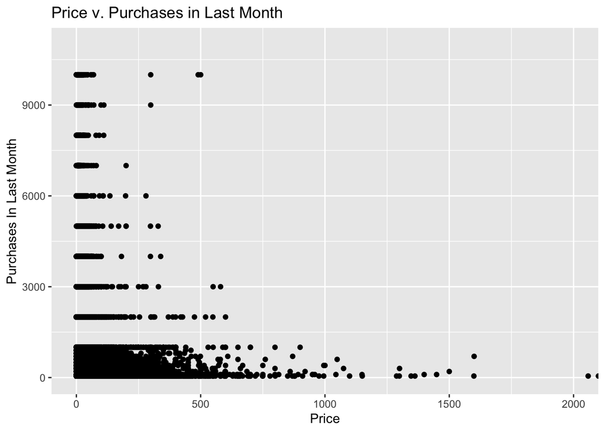

```r
library(ggplot2)
library(dplyr)

# read csv
amazon_all <- read.csv("/Users/annielu/Desktop/info201 hw/exploratory-analysis-lu-annie/amazon_all.csv")

# select only price and boughtInLastMonth columns
amazon_all_2 <- select(amazon_all, price, boughtInLastMonth)

# plot scatterplot with ggplot2 and set zoom
ggplot(amazon_all_2, aes(x = price, y = boughtInLastMonth)) +
  geom_point() +
  labs(title = "Price v. Purchases in Last Month",
       x = "Price",
       y = "Purchases In Last Month") +
  coord_cartesian(xlim = c(0, 2000), ylim = c(0, 11000))
```

## Chart 3

The purpose of Chart 3 is to answer research question 4: What is the average price of products per category on Amazon? This is done to find any relationships between categories and prices of items.

The insights from Chart 3 show the top 5 categories with the highest average price of products. There is not enough room to showcase more categories, but we can repeat this with lowest average prices to see what categories have cheaper and more expensive products, and if there is any correlation with how the product is rated as well.

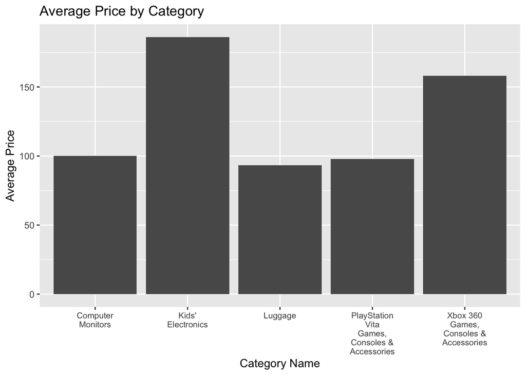

```r
library(ggplot2)
library(dplyr)
library(stringr)

# read csv
amazon_all <- read.csv("/Users/annielu/Desktop/info201 hw/exploratory-analysis-lu-annie/amazon_all.csv")

# create group by and summarize all categories with average prices and only show top 5
category_price_summaries <- amazon_all %>%
  group_by(category_name) %>%
  summarize(avg_price = mean(price)) %>%
  arrange(desc(avg_price)) %>%
  slice_head(n = 5)

# wrap for x axis labels
category_price_summaries$category_name <- str_wrap(category_price_summaries$category_name, width = 10)

# plot bar chart with ggplot2
ggplot(category_price_summaries, aes(x = category_name, y = avg_price)) +
  geom_bar(stat = "identity") +
  labs(title = "Average Price by Category",
       x = "Category Name",
       y = "Average Price") +
  theme(axis.text.x = element_text(size = 8))
```